# Activity 6: CLUSTERING

Fakhraddin Jaf

March 19, 2017

## Unsupervised clustering of the “Diabetes” data set, using K-Means

#### Loading required libraries:

```r
library("clValid")
library('fpc')
library('plotly')
options(error=traceback)
```

#### Read the dataset

```r
diabetes.orig <- read.csv(file="diabetes.csv", header=TRUE,sep=";",dec=".",na.strings="")

# Selecting some attributes, and removing the samples with NAs
diabetes.df <- na.omit(diabetes.orig[,c("chol","stab.glu","hdl","ratio","glyhb")])
```

### A) PROCESSING WITH **`clValid`** PACKAGE

#### 1) Reporting validation measures for clustering results by `clValid` function:

The R package **clValid** contains functions for validating the results of a clustering analysis. The type of cluster validation measures we use here is “internal”, and the clustering algorithms will be “K-means”.  
**Internal validation** measures take only the dataset and the clustering partition as input and uses inner information in the data to assess the quality of the clustering. The internal validation measures are the **connectivity**, **silhouette width**, and **Dunn index**.  
**K-means** is an iterative method which minimizes the within-class sum of squares for a given number of clusters. The algorithm starts with an initial guess for the cluster centers, and each observation is placed in the cluster to which it is closest. The cluster centers are then updated, and the entire process is repeated until the cluster centers no longer move.

```r
# Study the validity of the obtained clusters for clusterings from 2 to 10 clusters
internal_val <- clValid(diabetes.df, 2:10, clMethods=c("kmeans"), validation="internal")

# The optimal scores are obtained from 'clValid' result:
optimal_results <- optimalScores(internal_val)
summary(internal_val)
```

```
##
## Clustering Methods:
##  kmeans
##
## Cluster sizes:
##  2 3 4 5 6 7 8 9 10
##
## Validation Measures:
##                             2        3        4        5        6        7        8        9       10
##
## kmeans Connectivity   11.7683  66.5536  68.9333  71.1925  74.9583  79.0651  99.8052 110.9718 118.3623
##        Dunn            0.0516   0.0107   0.0068   0.0206   0.0254   0.0254   0.0321   0.0082   0.0082
##        Silhouette      0.6078   0.3740   0.3837   0.3885   0.3892   0.3891   0.3193   0.3144   0.3146
##
## Optimal Scores:
##
##              Score   Method Clusters
## Connectivity 11.7683 kmeans 2
## Dunn          0.0516 kmeans 2
## Silhouette    0.6078 kmeans 2
```

As seen from above, the omptimal number of clusters for each of these three validation measures, is 2.

**Ploting the clustering validity measure values:**

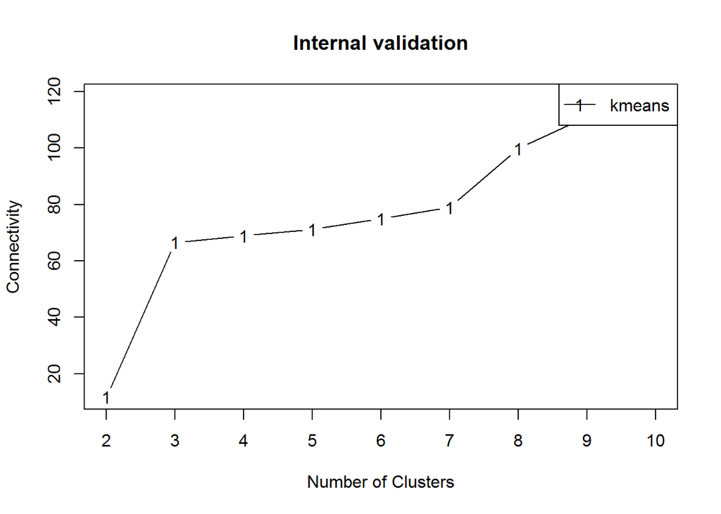

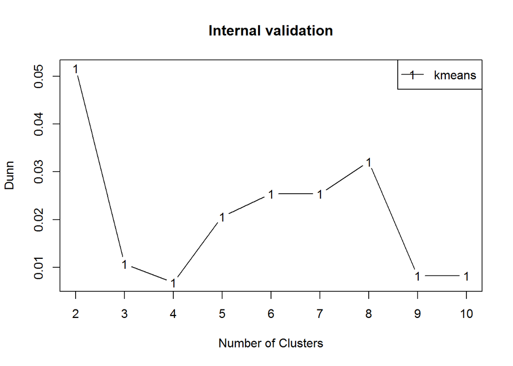

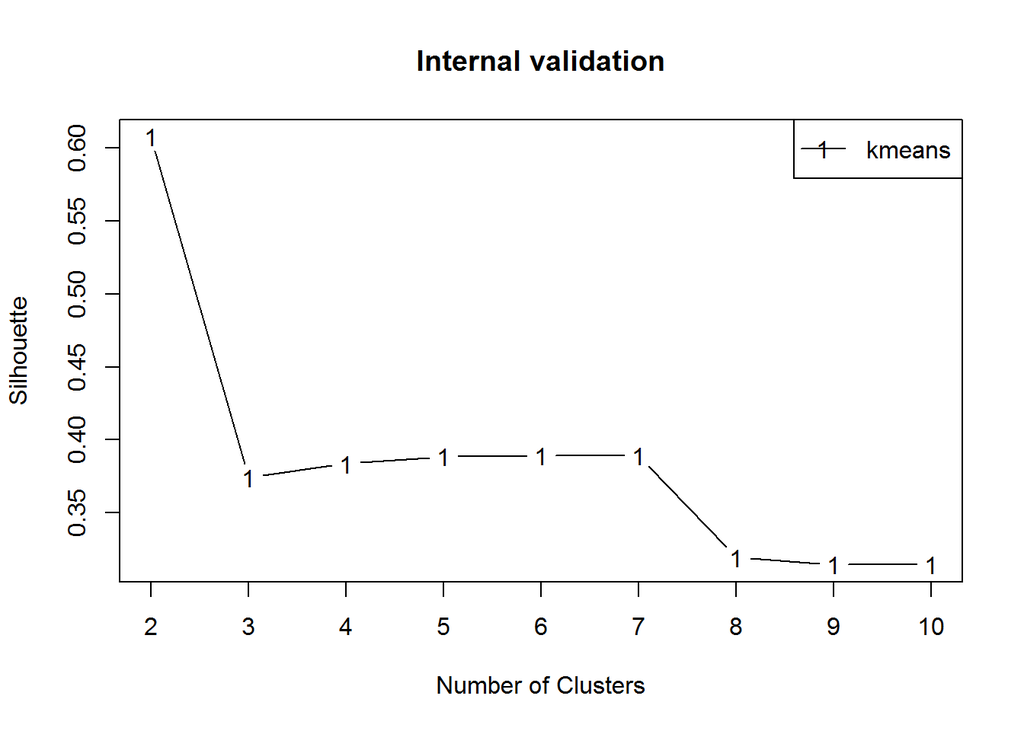

```r
plot(internal_val)
```

#### 2) The clustering for the optimal number of clusters (based on “Silhouette width”), plotted with the **`pairs`** function.

The **silhouette width** is the average of silhouette values of each observation. The silhouette value measures the degree of confidence in the clustering assignment of a particular observation, with well-clustered observations having values near 1 and poorly clustered observations having values near -1. In our case, the best value is **0.6078** , when the number of clusters is **2**.

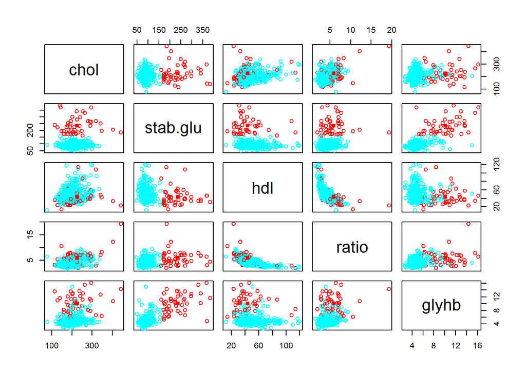

```r
# using "kmeans" function to run the "K-Means" algorithm, (number of clusters: 2) on data set:
NumClusters1 <- as.integer(as.matrix(optimal_results['Silhouette','Clusters']))
kc <- kmeans(diabetes.df, NumClusters1)
my_colors1 <- rainbow(NumClusters1)

# Plot the clustering results according to the all attributes
pairs(rbind(diabetes.df,kc$centers),col=c(my_colors1[kc$cluster],my_colors1),
                       pch=c(rep(1,nrow(diabetes.df)),rep(15,NumClusters1)))
```

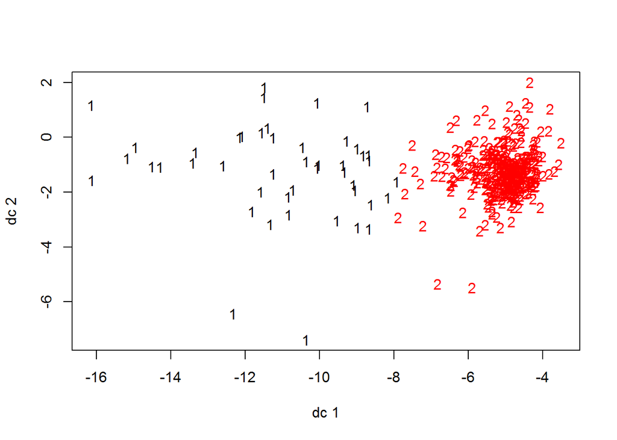

```r
#Ploting the optimal clustering on discriminant coordinates:
plotcluster(diabetes.df,kc$cluster)
```

### B) PROCESSING WITH **`fpc`** PACKAGE

The R package **fpc** contains various methods for clustering and cluster validation including estimating the number of clusters with **kmeans** algorithm. For this porpuse we will use the function **kmeansruns()**, which is based on k-means clustering, but initializes the k-means algorithm several times with random points from the data set as means.  
Meantime, we will run **kmeansruns()** two times, each with different value for criterion Argument, “asw” or “ch”, which determines whether **average silhouette width** or **CalinskiHarabasz** will be applied for validation.

#### 1) Applying **“average silhouette width”** criteria to optimize the number of clusters automatically, then plotting with the **`pairs`** function:

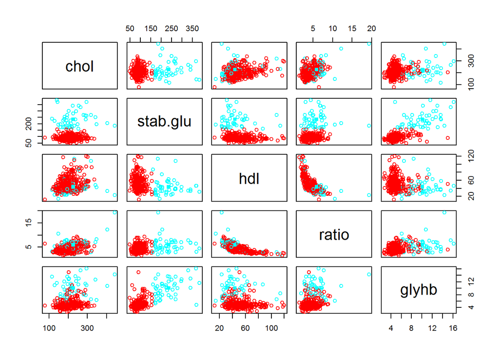

```r
# using "kmeansruns" function to run the "K-Means" algorithm to find out the optimal number of clusters, determined by the "average silhouette width(asw)":
zc_asw <- kmeansruns(diabetes.df ,  criterion = "asw")
NumClusters2 <- zc_asw$bestk
my_colors2 <- rainbow(NumClusters2)

# Plot the clustering results according to the all attributes
pairs(rbind(diabetes.df,zc_asw$centers),col=c(my_colors2[zc_asw$cluster],my_colors2),
                               pch=c(rep(1,nrow(diabetes.df)),rep(15,NumClusters2)))
```

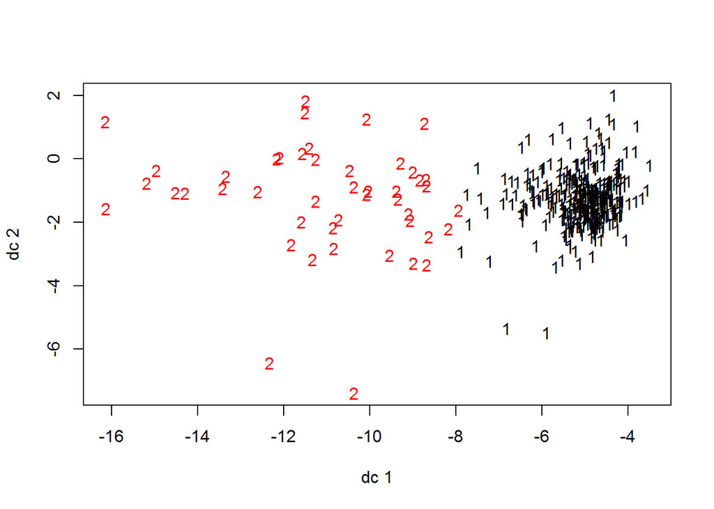

```r
#Ploting the optimal clustering on discriminant coordinates (obtained by applying "average silhouette width" criteria:
plotcluster(diabetes.df,zc_asw$cluster)
```

#### 2) Applying **“Calinski-Harabasz”** criteria to optimize the number of clusters automatically, then plotting with the **`pairs`** function:

Calinski-Harabasz index (also known as the variance ratio criterion) is an another internal clustering criterion used to evaluate the optimal number of clusters.

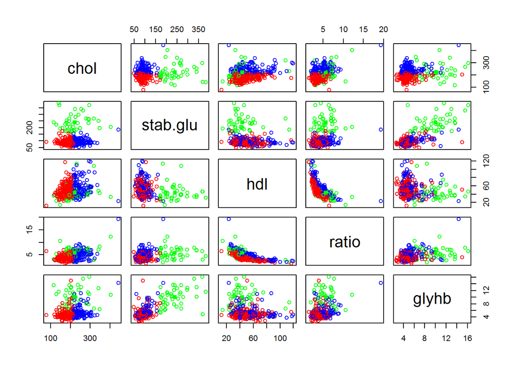

```r
# using "kmeansruns" function to run the "K-Means" algorithm to find out the optimal number of clusters, determined by the "Calinski-Harabasz (ch)" criteria:
zc_ch <- kmeansruns(diabetes.df ,  criterion = "ch")
NumClusters3 <- zc_ch$bestk
my_colors3 <- rainbow(NumClusters3)

# Plot the clustering results according to the all attributes
pairs(rbind(diabetes.df,zc_ch$centers),col=c(my_colors3[zc_ch$cluster],my_colors3),
                             pch=c(rep(1,nrow(diabetes.df)),rep(15,NumClusters3)))
```

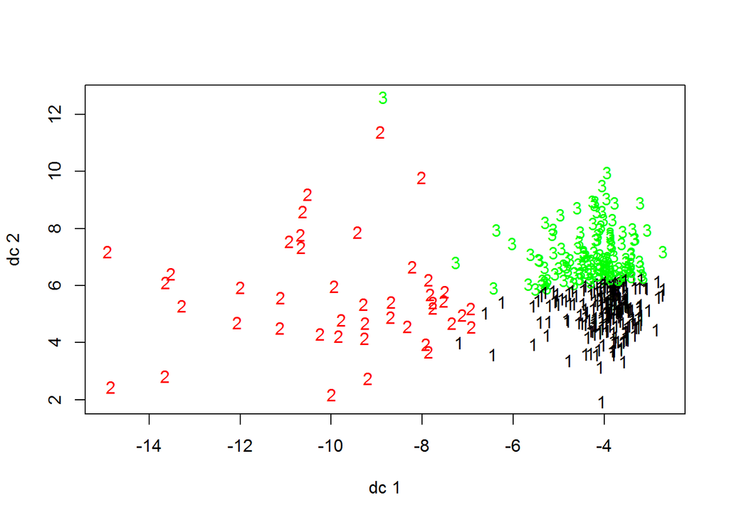

```r
#Ploting the optimal clustering on discriminant coordinates (obtained by applying "Calinski-Harabasz" criteria:
plotcluster(diabetes.df,zc_ch$cluster)
```

### C) Comparing Results:

#### The optimal number of clusters are compared in below plot:

```r
Method_name <- c("clValid_Connectivity", "clValid_Dunn", "clValid_Silhouette", "fpc_average_silhouette_width", "fpc_Calinski_Harabasz")

values <- as.integer(c(as.matrix(optimal_results)[1,3], as.matrix(optimal_results)[2,3], as.matrix(optimal_results)[3,3], zc_asw$bestk, zc_ch$bestk))

optimal_clusters <- data.frame("Method_name" = Method_name, "values" = values)
plot_ly(optimal_clusters, x = ~Method_name, y = ~values, type = 'bar', alpha = 0.8) %>%
        layout(title = "Number of optimal clusters",
               yaxis = list(title = '# of optimal clusters', range = c(0, 5)),
               xaxis= list(title = "", tickangle = 20) , margin = (b = 500) )
```

[interactive chart not shown]

**As seen from the plot, in all clustering evaluation structures, the number of optimal clusters for “Diabetes” data set is 2, unless in the case of using “Calinski-Harabasz index” by `fpc` package, which is 3.**